# Evolutionary analysis - Phylogenetic tree inference by maximum likelihood

Arthur Zwaenepoel - arzwa@psb.vib-ugent.be

# Software requirements

- An alignment viewer of your choice (suggestions: alv, [aliview](https://ormbunkar.se/aliview/), seaview)
- IQ-TREE 1.6 (http://www.iqtree.org/)

```python
import numpy as np
import matplotlib.pyplot as plt
import random as rnd
from scipy import linalg
from ete3 import Tree, NodeStyle, TreeStyle
plt.rcParams.update({"font.size":22})
```

```python
def setstyle(tree):
    ts = TreeStyle()
    ts.show_leaf_name = True
    nstyle = NodeStyle()
    nstyle["shape"] = "sphere"
    nstyle["size"] = 0
    for n in tree.traverse():
        n.set_style(nstyle)
    return ts
```

# Notation & definitions

Molecular phylogenetics requires being somewhat comfortable with probability theory and statistics. For clarity's sake, let's fix/refresh some notation and definitions:

An **event** $A$ can refer to any proposition, e.g. "Two birds are born in the next five minutes". Typically we associate events with a **sample space**, which could here be all possible numbers of birds.

In many cases, an event $A$ can be associated with a **probability** $P(A)$ (which you intuitively grasp, but can be defined in different ways, leading to philosophical minefields). By $P(A|B)$ we denote the **conditional probability**, that is the probability of event $A$ given that some other event $B$ occurred.

A **random variable** $X$ is a mapping from events to a real number. With a random variable, we asociated a function $p(X)$, known as the **probability mass/density function (pmf/pdf)** of the random variable $X$.

The data $D$ will always be a set of *aligned* molecular sequences, either amino acids, nucleotides or codons. An alignment represents a **hypothesis of homology**, i.e. it states our beliefs on which characters in a bunch of sequences have been derived from a common ancestral character.

# Maximum Likelihood

## Statistical principles

The **likelihood is a function of the parameters** of interest $\theta$ and is related to the probability of observing data $D$ under some **probabilistic model** $\mathcal{M}$. We write:

$$\mathcal{L}(\theta|D,\mathcal{M}) = P(D|\theta,\mathcal{M})$$

Maximum likelihood estimation is a technique for **estimating parameters** (i.e. coming up with an estimate $\hat{\theta}$ for the *unknown* parameter(s) $\theta$) of a probabilistic model where we try to find the values of $\theta$ that correspond to a maximal likelihood, that is

$$\hat{\theta} = \mathrm{argmax}_{\theta}\mathcal{L}(\theta|D,\mathcal{M}) $$

**Example:** For the last 10 years you observed whether on the first of May there was a magpie in your garden, you wrote 1 if there was at least one and 0 if there was none. Your data set looks as follows:

```python
magpies = [0,1,1,1,0,1,1,0,0,1]
```

What is the maximum likelihood estimate for the probability of having a magpie in your garden on the first of May?

Our random variable $X$ takes on two values, either $X = 1$ or $X = 0$. The probabilistic model $\mathcal{M}$ we use is a very simple one: every year on the first of May there is either a magpie in your garden ($X = 1$), which happens with probability $P(X = 1|\mathcal{M}) = \theta$, or there is no magpie ($X = 0$), with probability $P(X = 0| \mathcal{M}) = 1-\theta$ (in technical terms, your model is a so-called [Bernouilli process](https://en.wikipedia.org/wiki/Bernoulli_process)).

Recall that the likelihood is

$$\mathcal{L}(\theta|D,\mathcal{M}) = P(D|\theta,\mathcal{M})$$

Since we assume that the different observations are independent, $P(D|\theta, \mathcal{M})$ is simply

\begin{eqnarray} \mathcal{L}(\theta|D,\mathcal{M}) &=& P(D|\theta, \mathcal{M}) \\ &=& p(X_1 = 0, X_2 = 1, \cdots| \theta, \mathcal{M}) \\ &=& p(X_1 = 0| \theta, \mathcal{M})p(X_2 = 1| \theta, \mathcal{M})\cdots \\ &=& \theta^6(1-\theta)^4 \end{eqnarray}

Since this is a function of $\theta$, we can make the following plot:

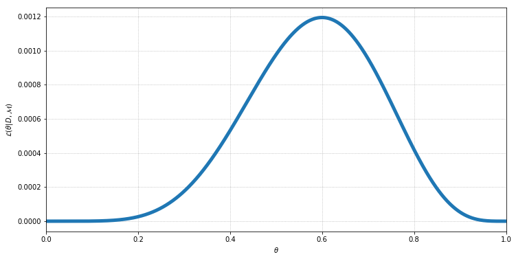

```python
fig, ax = plt.subplots(1,1,figsize=(12,6))
ax.plot(np.linspace(0,1,1000), [(1-x)**4*x**6 for x in np.linspace(0,1,1000)], linewidth=5);
ax.set_xlim(0, 1)
ax.set_xlabel("$\\theta$")
ax.set_ylabel("$\mathcal{L}(\\theta|D, \mathcal{M})$")
ax.grid(linestyle=":")
```

Unsurprisingly, the MLE is simply $\hat{\theta} = 0.6$, the fraction of times we saw a magpie.

Note that in this example, $X$ is a discrete random variable. The same principles apply for continuos random variables, but we replace probabilities and probability mass functions by probability *densities*.

# Phylogenetic likelihood

## Markov models of nucleotide substitution and the rate matrix

In order to do statistical phylogenetics, we need **a probabilistic model of sequence evolution**. This is a model that allows us to associate a probability to the event that sequence $a$ evolved to sequence $b$ over a certain time $t$. These are the so-called substitution models that you have discussed (e.g. JC69, K80, F81, HKY85, GTR, ...).

Substitution models are **Markov models** that describe **transitions between states** (e.g. `A, T, C, G` in the case of nucleotide sequences) at a particular alignment site.

The substitution model is fully determined by it's **rate matrix $Q$**. The entries in $Q$ are simply the rates at which substitution occur from one nucleotide to another, which is a random process (a [Poisson process](https://en.wikipedia.org/wiki/Poisson_point_process)) with waiting times between two substitution events having an exponential ditribution. This is very similar to for example radio-active decay.

$$Q = \begin{bmatrix} - & \lambda_{GA} & \lambda_{CA} & \lambda_{TA} \\ \lambda_{AG} & - & \lambda_{CG} & \lambda_{TG} \\ \lambda_{AC} & \lambda_{GC} & - & \lambda_{TC} \\ \lambda_{AT} & \lambda_{GT} & \lambda_{CT} & - \end{bmatrix}$$

**Example:** Here is a pretty inefficient way to *simulate* sequence evolution using a given rate matrix (here the JC69 matrix). Try to understand the simulation code. Remember, substitution is modeled as a Poisson process, resulting in an exponentially distributed waiting time between substitution events.

```python
Q = np.array([[ -1, 1/3, 1/3, 1/3],
              [1/3,  -1, 1/3, 1/3],
              [1/3, 1/3,  -1, 1/3],
              [1/3, 1/3, 1/3,  -1]])
```

```python
def simulateQ(Q, seq="AAAAA", t=2):
    # just a map from nucleotides to indices of the matrix (and reverse)
    charmap = {"A":0, "G":1, "C":2, "T":3}
    invmap  = {v: k for k, v in charmap.items()}
    newseq = ""
    # loop over independently evolving sites
    for site in seq:
        # get indices of the nucleotide and the ones it can substitute to
        state = charmap[site]
        other = list(set(range(4)) - set([state]))
        # start with a time `t` and draw the time until the first substitution
        t_  = t
        t_ -= np.random.exponential(sum(Q[other, state]))
        while t_ > 0:
            # pick a state to substitute to
            psubs = Q[other, state]/sum(Q[other, state])
            state = np.random.choice(other, p=psubs)
            other = list(set(range(4)) - set([state]))
            # draw the waiting time for the next
            t_ -= np.random.exponential(sum(Q[other, state]))
        # add character to the new sequence
        newseq += invmap[state]
    print("alignment:")
    print("\tseq(t={:5.1f}) ".format(0) + seq)
    print("\tseq(t={:5.1f}) ".format(t) + newseq)
    return newseq
```

```python
simulateQ(Q, seq="A"*50, t=100);
```

```
alignment:
	seq(t=  0.0) AAAAAAAAAAAAAAAAAAAAAAAAAAAAAAAAAAAAAAAAAAAAAAAAAA
	seq(t=100.0) GGGAACCGCGATAAGCGGCAAAGCACCTAAAATCGGTGCATAGACTCCGG
```

**Questions:**

1. What is the total rate of substitution from state `C` to any other nucleotide?
2. What happens to the sequence as $t$ increases?
3. What is the base composition for large $t$?
4. What are the main reasons why the JC69 model might be too unrealistic?
5. How would you change the rate matrix if I told you that transitions (`A <-> G`, `C <-> T`) are 10 times as likely as transversions (all other possible substitutions)

Associated with this rate matrix is the **transition probability matrix**

$$ P(t) = e^{Qt} $$

You might not know how to compute a matrix exponential, but all you need to know is that it's not that hard. The transition probability matrix is very similar to $Q$, but does not give the rates of the exponential ditributions of the substitution process, but probabilities of transitions. That is, $P_{ij}(t)$ gives the probability that nucleotide $i$ is substituted by nucleotide $j$ over time $t$.

**Example:** here is some very simple code to compute a matrix exponential using `scipy`

```python
Q = np.array([[ -1, 1/3, 1/3, 1/3],
              [1/3,  -1, 1/3, 1/3],
              [1/3, 1/3,  -1, 1/3],
              [1/3, 1/3, 1/3,  -1]])
```

```python
t = 0.2
P = linalg.expm(Q*t)
P
```

```
array([[0.82444625, 0.05851792, 0.05851792, 0.05851792],
       [0.05851792, 0.82444625, 0.05851792, 0.05851792],
       [0.05851792, 0.05851792, 0.82444625, 0.05851792],
       [0.05851792, 0.05851792, 0.05851792, 0.82444625]])
```

**Questions**

1. What happens to $P$ as $t$ increases?
2. Does the same thing happen when transitions are 10 times as likely as transversions (cfr. question above)?
3. What is the probability that for two sequences that are $t=1$ apart, at site 1 an `A` has been substituted by a `T` and at another independent site a `C` has been substituted by a `T`.
4. How would you simulate the evolution of a sequence over a time $t$ by using $P$ instead of $Q$ as above?

## Sequence likelihood on a phylogenetic tree

The markov model of the substitution process and its associated transition probability matrix provides us the probabilistic model $\mathcal{M}$ needed to compute the **likelihood of a phylogenetic tree given sequence data** $D$. More precisely, the probabilistic model is the substitution process described above, but now running along the branches of a tree structure. At every split in the tree, the substitution process splits into two independent new subtitution processes. Our goal is now to, based on **a set of sequences observed at the tips of the tree**, compute the likelihood of the tree topology $T$, its branch lengths $b$, and the parameters of the substitution process $\theta$, that is

$$\mathcal{L}(T, b, \theta|D, \mathcal{M}) = P(D|T, b, \theta, \mathcal{M})$$

It turns out that te only thing we need to do this is the transition probability matrix $P = e^{Qt}$ described above, and a clever algorithm (Felsenstein's pruning algorithm).

**Example:** Here is a very simple (and not the most efficient implementation) of Felsenstein's pruning algorithm. It is implemented in a recursive fashion. Try to understand why it is able to compute the likelihood for a given site given the tree, branch lengths and substitution model.

```python
def site_likelihood(tree, site, Q, verbose=False):
    charmap = {"A":0, "G":1, "C":2, "T":3}

    # recursion function
    def walk(n):
        # if we are at a leaf, the recursion ends (we know the state)
        if n.is_leaf():
            state = charmap[site[n.name]]  # get the state
            pvec = np.zeros(4)             # initialize the probability vector
            pvec[state] = 1                # set p[state] = 1
            if verbose:
                print("{:>10}".format(n.name), pvec)
            return pvec
        # we are at an internal node
        else:
            node_pvec = np.ones(4)         # initialize a probability vector of ones
            for c in n.children:           # recurse over the child nodes
                tmp_pvec = np.zeros(4)
                child_pvec = walk(c)       # recursion! get the p-vector at the child node
                P = linalg.expm(Q*c.dist)  # compute the P matrix
                for i in range(4):
                    tmp_pvec += P[i, :] * child_pvec[i]
                node_pvec *= tmp_pvec
            if verbose:
                print("{:>10}".format(",".join(n.get_leaf_names())), node_pvec)
            return node_pvec

    # do recursion and return the probability vector at the root
    return sum(walk(tree))
```

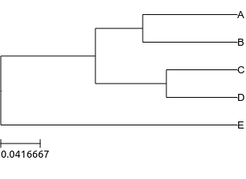

```python
tree = Tree("(((A:0.1,B:0.1):0.05,(C:0.075,D:0.075):0.075):0.1,E:0.25);")
ts = setstyle(tree)
ts.scale=1200
ts.branch_vertical_margin=20
tree.render("%%inline", tree_style=ts)
```

```python
site_likelihood(tree, {"A":"A", "B":"A", "C":"T", "D":"A", "E":"T"}, Q, verbose=True)
```

```
         A [1. 0. 0. 0.]
         B [1. 0. 0. 0.]
       A,B [0.82152468 0.00097386 0.00097386 0.00097386]
         C [0. 0. 0. 1.]
         D [1. 0. 0. 0.]
       C,D [0.02209266 0.00056599 0.00056599 0.02209266]
   A,B,C,D [1.64720048e-02 2.25877634e-05 2.25877634e-05 2.99251377e-04]
         E [0. 0. 0. 1.]
 A,B,C,D,E [1.05880119e-03 3.85909346e-05 3.85909346e-05 6.19431945e-04]
```

```
0.0017554150020707903
```

**Questions:**

1. Can you see where the three components, (1) topology, (2) branch lengths and (3) substitution model, come into play in the algorithm?
2. What is the order that the nodes are visited in during the recursion?
3. What would you think is the most likely recontruction of ancestral nucleotides, i.e. what is the most likely common state at each internal node?

Now we had the likelihood for a given site (i.e. a column of an alignment), but what about a **full alignment**? Since we assume independent evolution across the sites of the alignment, the alignment likelihood is just the product of the site-wise likelihoods (or the sum when working in log space).

```python
def aln_likelihood(tree, aln, Q):
    lhood = 0
    for i in range(len(list(aln.values())[0])):
        site = {k: v[i] for k, v in aln.items()}
        site_lhood = np.log(site_likelihood(tree, site, Q))
        lhood += site_lhood
    return lhood
```

```python
aln = {"A":"AAATATAAAGTATTTATAC",
       "B":"AAGTATCAAGTATGGATAC",
       "C":"TACTACCAAGGGGTTATAC",
       "D":"AATTACCAAGTATTCTGAC",
       "E":"ATTTCCCAGTAATCCTGCC" }
```

```python
aln_likelihood(tree, aln, Q)
```

```
-83.41068879674272
```

## The maximum likelihood tree

So this gives us the likelihood of a data set given that we know everything, i.e. the topology, branch lengths and substitution model parameters. That is of course silly, because we are looking for eactly these things. Under the ML principle we can however use this likelihood to try and find the parameters, branch lengths and topology that *maximize* this likelihood. That is, we try to solve the following problem:

$$\hat{T}, \hat{b}, \hat{\theta} = \mathrm{argmax}_{T,b,\theta}\mathcal{L}(T, b, \theta|D, \mathcal{M})$$

**Example:**

### Finding the MLE of a single branch length

```python
node = tree.get_leaves_by_name("A")[0]
lhood = []
x = np.linspace(0,0.5,100)
for b in x:
    node.dist = b
    lhood.append(aln_likelihood(tree, aln, Q))
```

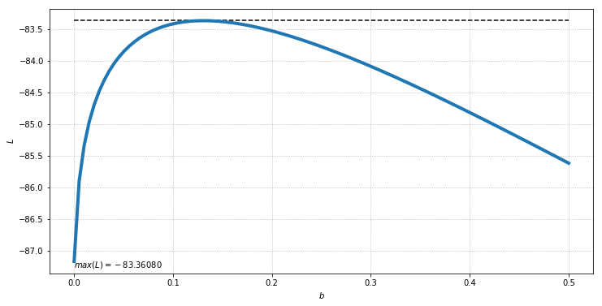

```python
fig, ax = plt.subplots(1,1,figsize=(12,6))
ax.plot(x, lhood, linewidth=4);
ax.hlines(max(lhood), xmin=0, xmax=max(x), linestyles="--")
y1, y2 = ax.get_ylim()
ax.text(s="$max(L) = {:.5f}$".format(max(lhood)), x=0, y=y1+.1)
ax.grid(linestyle=":")
ax.set_xlabel("$b$")
ax.set_ylabel("$L$");
```

Branch lengths and substitution model parameters can normally be efficiently optimized using general optimziation techniques (e.g. Newton's method, seics, and the course "Selected topics in mathematical optimization" in the second year of the Master in Bioinformatics).

## Heuristic tree search

Tree topologies however provide a big challenge for the optimization. Finding the topology that maximizes the likelihood is an intractable combinatorial problem. Recall that tree space is *huge*, so computing the likelihood for all possible tree topologies is certainly no option.

Instead, we have to resort to a **heuristic search through tree space**. The basic approach is a greedy hill climbing strategy. This works as follows (where $\theta$ denotes all parameters of the model (excluding the topology), i.e. branch lengths and parameters of the substitution models):

Tree topology $T$, branch lengths $b$ and parameters of substitution model $\theta$

1. Start with a random tree $T$, find the ML estimates for $\theta$ and $b$ and compute the likelihood $L$
2. Modify the tree using some kind of tree rearrangement move to get a new topology $T'$
3. Search for the ML estimates of $\theta$ and $b$ given $T'$ and compute the likelihood $L'$ of the new tree $T'$
4. If $L' > L$ set $T \leftarrow T' $ and $L \leftarrow L'$
5. If some convergence condition is met, stop, else go back to step 2

Some important 'tree moves' are shown here:

[figure not shown]

This may look quite simple, but to get a sufficiently efficient algorithm, *a lot* of engineering comes into play... And that's why there is highly efficient software available for these purposes! The main **tools** for ML tree inference are

1. PhyML and co. (the first really efficient one)
2. RaxML and co. (the first really really efficient one, especially good for really large data sets and parallel computing)
3. IQ-TREE and co. (probably the most comprehensive one currently available)

We will now use IQ-TREE to do some tree inference ourselves!

## Exercise: tree inference using IQ-TREE

We will work with some nice example data sets from the [OrthoMaM database](http://orthomam2.mbb.univ-montp2.fr/OrthoMaM_v10b2/), which is a set of curated gene families with alignments available for a large number of mammalian species. If you prefer plants, you can get similar data on [PLAZA](https://bioinformatics.psb.ugent.be/plaza/versions/plaza_v4_dicots/).

Go to the OrthoMaM database, to the `search marker` tab, and enter a gene family ID, for example `ENSG00000004897`, `ENSG00000169139`, `ENSG00000092054`, .... Download the alignments (nucleotide and amino acid) and have a look at them in an alignment viewer. For example, if you are on linux and have `alv` installed, you can do in a terminal: `alv -l ENSG00000004897_CDC27_NT.fasta | less -RS`. Have a look at the alignment to get to know your data set.

Next, we will infer a tree using IQ-TREE. IQ-TREE is quite user friendly, with very advanced default settings. This makes it an easy tool to infer accurate ML trees, but it also makes it quite easy for a researcher to do a lot of analyses without actually understanding what's going on under the hood. We will try to prevent doing stuff we don't understand!

**Tip:** If you want to use the parallel version of IQ-TREE and use multiple CPU cores to infer trees, use `iqtree-omp` or `iqtree-mpi` with the flag `-nt <number of CPU cores>` instead of the default `iqtree`.

Let us begin with more or less the simplest possible analysis you could do with IQ-TREE, namely inferring the ML tree with the Jukes-Cantor model (**note**: I here select the platypus *Ornithorhynchus anatinus* as outgroup, this will of course only work if you have this species in the alignment that you are analyzing. You do not need to specify an outgroup of course, it's just nice for tree visualization):

```python
!iqtree -s ./data/ENSG00000004897_CDC27_NT.fasta -m JC69 -o Ornithorhynchus_anatinus -pre JC69 -redo
```

```
IQ-TREE version 1.5.5 for Linux 64-bit built Jun 19 2017
Copyright (c) 2011-2017 by Bui Quang Minh, Nguyen Lam Tung,
Olga Chernomor, Heiko Schmidt, and Arndt von Haeseler.

Host:    carey (AVX2, FMA3, 7 GB RAM)
Command: iqtree -s ./data/ENSG00000004897_CDC27_NT.fasta -m JC69 -o Ornithorhynchus_anatinus -pre JC69 -redo
Seed:    236877 (Using SPRNG - Scalable Parallel Random Number Generator)
Time:    Thu Apr  4 13:44:30 2019
Kernel:  AVX+FMA

NOTE: Consider using the multicore version because your CPU has 4 cores!

Reading alignment file ./data/ENSG00000004897_CDC27_NT.fasta ... Fasta format detected
Alignment most likely contains DNA/RNA sequences
Alignment has 113 sequences with 2478 columns and 1175 patterns (698 informative sites, 1515 constant sites)
                                     Gap/Ambiguity  Composition  p-value
   1  Delphinapterus_leucas                  1.09%    passed     98.49%
   2  Pan_troglodytes                        1.33%    passed     96.05%
   3  Echinops_telfairi                      9.44%    passed     31.63%
   4  Tupaia_belangeri                      15.62%    passed     78.99%
   5  Sarcophilus_harrisii                  34.14%    passed     57.44%
   6  Rhinopithecus_bieti                    5.57%    passed     94.43%
   7  Panthera_tigris_altaica                1.09%    passed     97.44%
   8  Acinonyx_jubatus                       7.51%    passed     98.45%
   9  Ailuropoda_melanoleuca                 0.12%    passed     99.37%
  10  Canis_familiaris                       0.12%    passed     99.49%
  11  Ursus_maritimus                        0.12%    passed     99.96%
  12  Mustela_putorius                       0.12%    passed     96.77%
  13  Enhydra_lutris_kenyoni                 0.12%    passed     97.24%
  14  Neomonachus_schauinslandi              0.12%    passed     99.87%
  15  Felis_catus                            0.12%    passed     94.75%
  16  Panthera_pardus                        0.12%    passed     93.85%
  17  Vicugna_pacos                          0.48%    passed     95.30%
  18  Camelus_bactrianus                     0.12%    passed     99.23%
  19  Camelus_dromedarius                    0.12%    passed     98.96%
  20  Camelus_ferus                          0.12%    passed     99.40%
  21  Leptonychotes_weddellii                3.39%    passed     97.13%
  22  Odobenus_rosmarus_divergens            1.09%    passed     99.22%
  23  Sus_scrofa                             0.12%    passed     98.83%
  24  Bos_taurus                             0.12%    passed     98.31%
```

[output cut: 148 more lines]

```
Total tree length: 1.464

Total number of iterations: 102
CPU time used for tree search: 21.073 sec (0h:0m:21s)
Wall-clock time used for tree search: 21.073 sec (0h:0m:21s)
Total CPU time used: 21.281 sec (0h:0m:21s)
Total wall-clock time used: 21.284 sec (0h:0m:21s)

Analysis results written to:
  IQ-TREE report:                JC69.iqtree
  Maximum-likelihood tree:       JC69.treefile
  Likelihood distances:          JC69.mldist
  Screen log file:               JC69.log

Date and Time: Thu Apr  4 13:44:51 2019
```

**Questions:**

1. Go through the stuff IQ-TREE spitted out on the screen, can you figure out how IQ-TREE searches for the ML tree?
2. Open the `.iqtree` file and write down the final log-likelihood of the ML tree. Have a look at the `SUBSTITUTION PROCESS` section. Do you understand what is in there?
3. Now visualize the tree in the `.treefile` file or load it in some tree viewer (e.g. [IcyTree](https://icytree.org/) (online) or [figtree](https://github.com/rambaut/figtree/releases/tag/v1.4.4)). Did IQ-TREE with JC69 more or less recover the mammal tree as we know it?

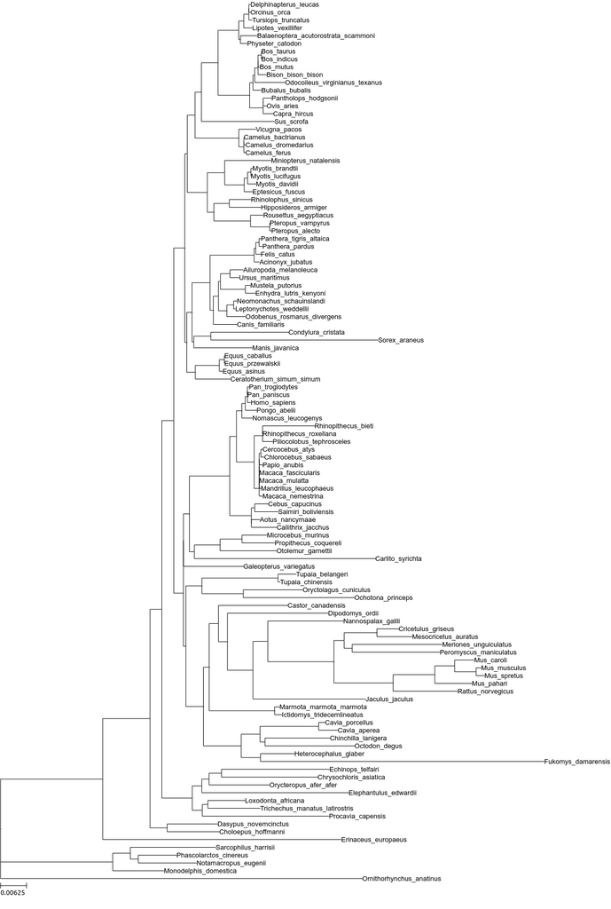

```python
tree = Tree("./JC69.treefile")
ts = setstyle(tree)
ts.scale=8000
tree.render("%%inline", tree_style=ts)
```

Now run IQ-TREE with the JC69 model with $\Gamma$-distributed rate heterogeneity across sites:

```python
!iqtree -s ./data/ENSG00000004897_CDC27_NT.fasta -m JC69+G -o Ornithorhynchus_anatinus -pre JC69G -redo
```

```
IQ-TREE version 1.5.5 for Linux 64-bit built Jun 19 2017
Copyright (c) 2011-2017 by Bui Quang Minh, Nguyen Lam Tung,
Olga Chernomor, Heiko Schmidt, and Arndt von Haeseler.

Host:    carey (AVX2, FMA3, 7 GB RAM)
Command: iqtree -s ./data/ENSG00000004897_CDC27_NT.fasta -m JC69+G -o Ornithorhynchus_anatinus -pre JC69G -redo
Seed:    881657 (Using SPRNG - Scalable Parallel Random Number Generator)
Time:    Thu Apr  4 13:44:51 2019
Kernel:  AVX+FMA

NOTE: Consider using the multicore version because your CPU has 4 cores!

Reading alignment file ./data/ENSG00000004897_CDC27_NT.fasta ... Fasta format detected
Alignment most likely contains DNA/RNA sequences
Alignment has 113 sequences with 2478 columns and 1175 patterns (698 informative sites, 1515 constant sites)
                                     Gap/Ambiguity  Composition  p-value
   1  Delphinapterus_leucas                  1.09%    passed     98.49%
   2  Pan_troglodytes                        1.33%    passed     96.05%
   3  Echinops_telfairi                      9.44%    passed     31.63%
   4  Tupaia_belangeri                      15.62%    passed     78.99%
   5  Sarcophilus_harrisii                  34.14%    passed     57.44%
   6  Rhinopithecus_bieti                    5.57%    passed     94.43%
   7  Panthera_tigris_altaica                1.09%    passed     97.44%
   8  Acinonyx_jubatus                       7.51%    passed     98.45%
   9  Ailuropoda_melanoleuca                 0.12%    passed     99.37%
  10  Canis_familiaris                       0.12%    passed     99.49%
  11  Ursus_maritimus                        0.12%    passed     99.96%
  12  Mustela_putorius                       0.12%    passed     96.77%
  13  Enhydra_lutris_kenyoni                 0.12%    passed     97.24%
  14  Neomonachus_schauinslandi              0.12%    passed     99.87%
  15  Felis_catus                            0.12%    passed     94.75%
  16  Panthera_pardus                        0.12%    passed     93.85%
  17  Vicugna_pacos                          0.48%    passed     95.30%
  18  Camelus_bactrianus                     0.12%    passed     99.23%
  19  Camelus_dromedarius                    0.12%    passed     98.96%
  20  Camelus_ferus                          0.12%    passed     99.40%
  21  Leptonychotes_weddellii                3.39%    passed     97.13%
  22  Odobenus_rosmarus_divergens            1.09%    passed     99.22%
  23  Sus_scrofa                             0.12%    passed     98.83%
  24  Bos_taurus                             0.12%    passed     98.31%
```

[output cut: 168 more lines]

```
Total tree length: 1.739

Total number of iterations: 150
CPU time used for tree search: 91.930 sec (0h:1m:31s)
Wall-clock time used for tree search: 91.959 sec (0h:1m:31s)
Total CPU time used: 92.708 sec (0h:1m:32s)
Total wall-clock time used: 92.748 sec (0h:1m:32s)

Analysis results written to:
  IQ-TREE report:                JC69G.iqtree
  Maximum-likelihood tree:       JC69G.treefile
  Likelihood distances:          JC69G.mldist
  Screen log file:               JC69G.log

Date and Time: Thu Apr  4 13:46:24 2019
```

**Questions:**

1. In how many categories does IQ-TREE discretize the $\Gamma$ distribution by default? Can you draw (approximately) the discrete $\Gamma$ distribution estimated by IQ-TREE?
2. How much longer did it take to find the ML tree under the JC69 + $\Gamma$ model compared to the simple JC69 model?
3. Why wouldn't it simply take an amount of time equal to 'number of $\Gamma$ categories' $\times$ 'time under JC69'?
4. Write down the log-likelihood for the ML tree. Which model do you think fits the data best and why?

Now run IQ-TREE with the K2P (also called K80) model:

```python
!iqtree-omp -nt 4 -s ./data/ENSG00000004897_CDC27_NT.fasta -m K2P -o Ornithorhynchus_anatinus -pre K2P -redo
```

```
IQ-TREE multicore version 1.5.5 for Linux 64-bit built Jun 19 2017
Copyright (c) 2011-2017 by Bui Quang Minh, Nguyen Lam Tung,
Olga Chernomor, Heiko Schmidt, and Arndt von Haeseler.

Host:    carey (AVX2, FMA3, 7 GB RAM)
Command: iqtree-omp -nt 4 -s ./data/ENSG00000004897_CDC27_NT.fasta -m K2P -o Ornithorhynchus_anatinus -pre K2P -redo
Seed:    326810 (Using SPRNG - Scalable Parallel Random Number Generator)
Time:    Thu Apr  4 13:46:38 2019
Kernel:  AVX+FMA - 4 threads (4 CPU cores detected)

Reading alignment file ./data/ENSG00000004897_CDC27_NT.fasta ... Fasta format detected
Alignment most likely contains DNA/RNA sequences
Alignment has 113 sequences with 2478 columns and 1175 patterns (698 informative sites, 1515 constant sites)
                                     Gap/Ambiguity  Composition  p-value
   1  Delphinapterus_leucas                  1.09%    passed     98.49%
   2  Pan_troglodytes                        1.33%    passed     96.05%
   3  Echinops_telfairi                      9.44%    passed     31.63%
   4  Tupaia_belangeri                      15.62%    passed     78.99%
   5  Sarcophilus_harrisii                  34.14%    passed     57.44%
   6  Rhinopithecus_bieti                    5.57%    passed     94.43%
   7  Panthera_tigris_altaica                1.09%    passed     97.44%
   8  Acinonyx_jubatus                       7.51%    passed     98.45%
   9  Ailuropoda_melanoleuca                 0.12%    passed     99.37%
  10  Canis_familiaris                       0.12%    passed     99.49%
  11  Ursus_maritimus                        0.12%    passed     99.96%
  12  Mustela_putorius                       0.12%    passed     96.77%
  13  Enhydra_lutris_kenyoni                 0.12%    passed     97.24%
  14  Neomonachus_schauinslandi              0.12%    passed     99.87%
  15  Felis_catus                            0.12%    passed     94.75%
  16  Panthera_pardus                        0.12%    passed     93.85%
  17  Vicugna_pacos                          0.48%    passed     95.30%
  18  Camelus_bactrianus                     0.12%    passed     99.23%
  19  Camelus_dromedarius                    0.12%    passed     98.96%
  20  Camelus_ferus                          0.12%    passed     99.40%
  21  Leptonychotes_weddellii                3.39%    passed     97.13%
  22  Odobenus_rosmarus_divergens            1.09%    passed     99.22%
  23  Sus_scrofa                             0.12%    passed     98.83%
  24  Bos_taurus                             0.12%    passed     98.31%
  25  Pantholops_hodgsonii                   0.12%    passed     99.37%
  26  Bos_indicus                            0.12%    passed     98.31%
```

[output cut: 155 more lines]

```
Total tree length: 1.477

Total number of iterations: 102
CPU time used for tree search: 49.625 sec (0h:0m:49s)
Wall-clock time used for tree search: 14.560 sec (0h:0m:14s)
Total CPU time used: 50.721 sec (0h:0m:50s)
Total wall-clock time used: 14.888 sec (0h:0m:14s)

Analysis results written to:
  IQ-TREE report:                K2P.iqtree
  Maximum-likelihood tree:       K2P.treefile
  Likelihood distances:          K2P.mldist
  Screen log file:               K2P.log

Date and Time: Thu Apr  4 13:46:53 2019
```

**Questions:**

1. Interpret the relative rates and substitution matrix. What is the difference between K2P and JC69?
2. Write down the log-likelihood for the ML tree. Which model do you think fits the data best and why?

Lastly run IQ-TREE with the GTR model:

```python
!iqtree-omp -nt 4 -s ./data/ENSG00000004897_CDC27_NT.fasta -m GTR -o Ornithorhynchus_anatinus -pre GTR -redo
```

```
IQ-TREE multicore version 1.5.5 for Linux 64-bit built Jun 19 2017
Copyright (c) 2011-2017 by Bui Quang Minh, Nguyen Lam Tung,
Olga Chernomor, Heiko Schmidt, and Arndt von Haeseler.

Host:    carey (AVX2, FMA3, 7 GB RAM)
Command: iqtree-omp -nt 4 -s ./data/ENSG00000004897_CDC27_NT.fasta -m GTR -o Ornithorhynchus_anatinus -pre GTR -redo
Seed:    568785 (Using SPRNG - Scalable Parallel Random Number Generator)
Time:    Thu Apr  4 13:47:00 2019
Kernel:  AVX+FMA - 4 threads (4 CPU cores detected)

Reading alignment file ./data/ENSG00000004897_CDC27_NT.fasta ... Fasta format detected
Alignment most likely contains DNA/RNA sequences
Alignment has 113 sequences with 2478 columns and 1175 patterns (698 informative sites, 1515 constant sites)
                                     Gap/Ambiguity  Composition  p-value
   1  Delphinapterus_leucas                  1.09%    passed     98.49%
   2  Pan_troglodytes                        1.33%    passed     96.05%
   3  Echinops_telfairi                      9.44%    passed     31.63%
   4  Tupaia_belangeri                      15.62%    passed     78.99%
   5  Sarcophilus_harrisii                  34.14%    passed     57.44%
   6  Rhinopithecus_bieti                    5.57%    passed     94.43%
   7  Panthera_tigris_altaica                1.09%    passed     97.44%
   8  Acinonyx_jubatus                       7.51%    passed     98.45%
   9  Ailuropoda_melanoleuca                 0.12%    passed     99.37%
  10  Canis_familiaris                       0.12%    passed     99.49%
  11  Ursus_maritimus                        0.12%    passed     99.96%
  12  Mustela_putorius                       0.12%    passed     96.77%
  13  Enhydra_lutris_kenyoni                 0.12%    passed     97.24%
  14  Neomonachus_schauinslandi              0.12%    passed     99.87%
  15  Felis_catus                            0.12%    passed     94.75%
  16  Panthera_pardus                        0.12%    passed     93.85%
  17  Vicugna_pacos                          0.48%    passed     95.30%
  18  Camelus_bactrianus                     0.12%    passed     99.23%
  19  Camelus_dromedarius                    0.12%    passed     98.96%
  20  Camelus_ferus                          0.12%    passed     99.40%
  21  Leptonychotes_weddellii                3.39%    passed     97.13%
  22  Odobenus_rosmarus_divergens            1.09%    passed     99.22%
  23  Sus_scrofa                             0.12%    passed     98.83%
  24  Bos_taurus                             0.12%    passed     98.31%
  25  Pantholops_hodgsonii                   0.12%    passed     99.37%
  26  Bos_indicus                            0.12%    passed     98.31%
```

[output cut: 153 more lines]

```
Total tree length: 1.477

Total number of iterations: 109
CPU time used for tree search: 52.171 sec (0h:0m:52s)
Wall-clock time used for tree search: 15.171 sec (0h:0m:15s)
Total CPU time used: 53.094 sec (0h:0m:53s)
Total wall-clock time used: 15.448 sec (0h:0m:15s)

Analysis results written to:
  IQ-TREE report:                GTR.iqtree
  Maximum-likelihood tree:       GTR.treefile
  Likelihood distances:          GTR.mldist
  Screen log file:               GTR.log

Date and Time: Thu Apr  4 13:47:16 2019
```

**Questions:**

1. Interpret the relative rates and substitution matrix. What is the difference between GTR and K2P?
2. Are there strong differences in relative rates between different kinds of transitions/transversions?
3. Write down the log-likelihood for the ML tree. Which model (GTR or K2P) do you think fits the data best and why?

**Note:** IQ-TREE has fancy bootstrapping options to get an idea of the support for the clades found in the tree, these can be used by setting the `-bb` (for 'ultrafast bootstraps') setting when running IQ-TREE.

## Model selection

### Nested models - the LRT

In all the above, we have assumed that the substitution model $\mathcal{M}$ was given. There are however a tremendous number of substitution models that you could use! As already suggested in our comparison of JC69 with JC69+$\Gamma$, we need a way to find the model that best fits our data set. Intuitively, one could think of it as follows: we are searching for the substitution model that, when we simulate random sequences from the substitution process along the true tree topology with the true branch lengths starting from the true ancestral sequence, will give sequences at the tips that look a lot like our data set.

A general technique to perform model selection in a maximum likelihood setting is simply to compare the likelihood values for different candidate models using a so-called **likelihood ratio test** (LRT).

Consider two models, for example the Jukes & Cantor model (JC69) and the more complex Kimura model (K80). We can compute the maximum likelihood estimate and maximal likelihood values, call these maximal likelihood values $l_{JC69}$ and $l_{K80}$ repectively. We are interested whether the K80 model provide a better fit to the sequence data or whether the simpler JC69 model will do the job. The ratio of the maximal likelihood values

$$ \Lambda = \frac{l_{K80}}{l_{JC69}} $$

tells us how many times more likely the K80 model is to have generated the data compared to the JC69 model.

Note that simply knowing how many times more likely one model is to be the hypothetical true model does not tell us whether this difference is *statistically significant*. The likelihood ratio can be converted in a test statistic, the LRT, which allows us to assess the statistical significance of the difference in maximal likelihood values.

By [Wilks' theorem](https://en.wikipedia.org/wiki/Wilks%27_theorem), we know that the test statistic

where

- $l_1$ is the likelihood under model 1 with $k_1$ parameters
- $l_0$ is the likelihood under model 0 with $k_0$ parameters
- $k_1 > k_0$

The LRT only works however for **nested models**, i.e. the simpler model is a special case of the more parameter-rich model. Furthermore, Wilks' theorem only holds when the parameters are not at the boundary of the parameter space.

**Questions:**

1. What is the LRT test statistic for the K2P vs. JC69 model for the data set we used above?
2. Are the models nested? How so?
3. What is the difference in number of parameters for the K2P and JC69 model?
4. Is the difference in model fit statistically significant at the 5% level assuming the LRT follows the $\chi^2_{k_1 - k_0}$ distribution?
5. What about the above questions but for JC69 vs. JC69+$\Gamma$?
6. Can we compare JC69+$\Gamma$ with K2P using the LRT?

```python
from scipy.stats import chi2
test_statistic = 5
degrees_of_freedom = 1
chi2.pdf(test_statistic, degrees_of_freedom)
```

```
0.014644982561926487
```

### Information criteria

Some of the models are not nested, in that case we can use information criteria such as the **Akaike information criterion** (AIC) or **Bayesian information criterion** (BIC).

$$ AIC = 2k - 2ln(l) $$

The model with the lowest AIC value provides a better fit to the data. The value

$$ \mathrm{exp}\Big(\frac{AIC_{min} - AIC_i}{2}\Big) $$

is proportional to the probability that the $i^{th}$ model provides an equally well fit as the model with minimal AIC value.

### ModelFinder

IQ-TREE by default uses ModelFinder to automatically select the best fitting model based on AIC or BIC in an efficient way. ModelFinder works as follows (with default settings):

1. Find a reasonable tree $T$ (inferred using parsimony)
2. Find the maximal likelihood $L(D|T,\mathcal{M}_i)$ and associated parameters of the substitution model $\mathcal{M}_i$ for all $i$ where $\{\mathcal{M}\}_{1,\cdots,i}$ is a list of substitution models (and models of rate heterogeneity, e.g. $\Gamma$)
3. Identify $\mathcal{M}_\mathrm{optimal}$ using the $BIC$ criterion

**Questions:**

- What is the best fitting model according to ModelFinder?
- What is the probability that the JC69 model fits the data at least as well as the best fitting model?

Next up, the real deal: **Bayesian inference!**